# Using Machine Learning to Enable Guided Weight-Lifting

Essence91214

### Background and Problem Definition

Recent technological developments have enabled fitness enthusiasts to take measurements about themselves regularly to improve their health and to find patterns in their behavior. While it is easy to quantify the amount of a particular activity, it is challenging to access how well it is done. Such information, which is lacking currently, could be used as feedback to provide guidance to improve the quality of fitness training and exercises and therefore enhance ones physical state of being. Automatic accessment of the quality of exercise is the challenge we address in this study.

### Data Used in This Study

The Data used in this analysis was collected over a period of 8 hours from accelerometers on the belt, forearm, arm, and dumbell of 6 participants who performed a set of 10 repetitions of the Unilateral Dumbbell Biceps Curl in five different fashions:

- exactly according to the specification (Class A),
- throwing the elbows to the front (Class B),
- lifting the dumbbell only halfway (Class C),
- lowering the dumbbell only halfway (Class D), and
- throwing the hips to the front (Class E).

Class A corresponds to the specified execution of the exercise, while the other 4 classes correspond to common mistakes. Participants were supervised by an experienced weight lifter to make sure the execution complied to the manner they were supposed to simulate.

### Goal

- Build a prediction model for ‘classe’ variable,
- Calculate the out of sample error for the prediction model,
- Use the prediction model to predict the outcome for the 20 test cases provided, and
- Perform a diagnostic analysis of the model.

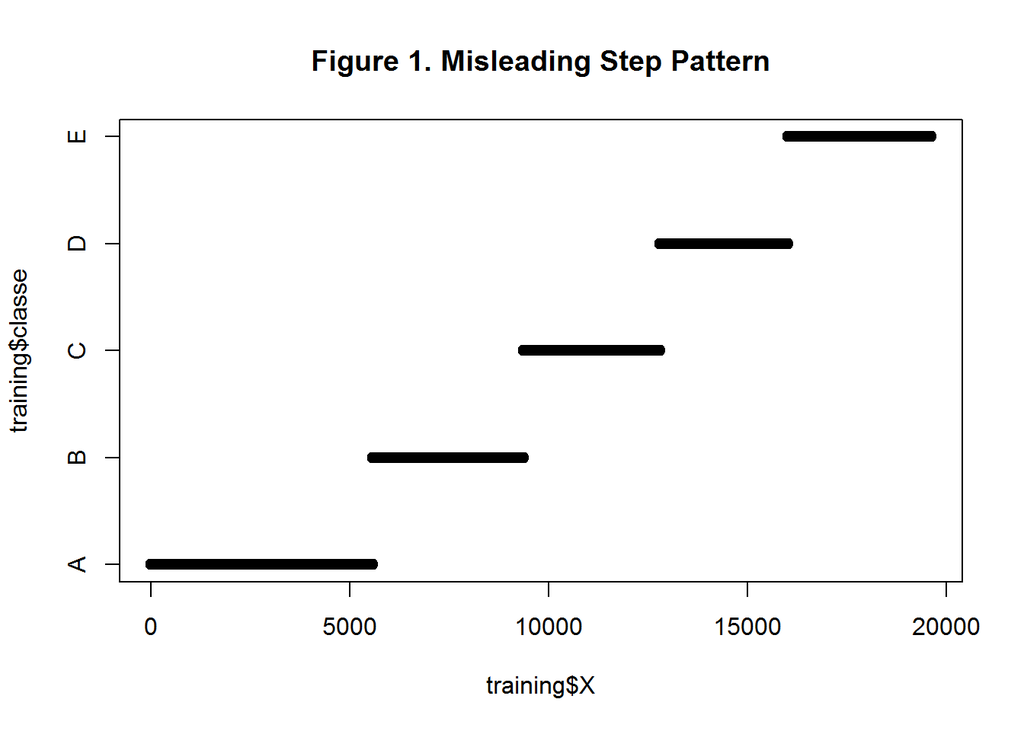

````r
#```{r echo = FALSE, warning = FALSE, message = FALSE, comment = FALSE}
#Loading data and packages
training <- read.csv("pml-training.csv")
testing <- read.csv("pml-testing.csv")
require(caret)
require(randomForest)
require(dplyr)
plot(training$X, training$classe, yaxt = "n", main = "Figure 1. Misleading Step Pattern")
axis(side = 2, at = 1:5,  labels =c("A", "B", "C", "D", "E"))
````

### Loading and Cleaning Data

The input training dataset has 19,622 observations and 160 variables including the ‘classe’ variable(160th). We examined the other 159 variables with the intent of removing variables that do not seem to contribute towards predicting the ‘classe’ variable.

### Splitting Data into Training and Validation Sets:

The amount of training data provided is enormous and executing a learning algorithm on that data took a large amount of computation time. Therefore we split the given training set into training(60%) and validation(40%) sets. We used the training set to build a classifier.

### Building A Model

We used Random Forests algorithm to build a classifier, which is briefly described below. We explored few other algorithms such as boosting, using ‘gbm’ from caret package. Since the accuracy achieved by Random Forests was always much larger than that achieved by the other algorithms, the trials with the other algorithms were discarded in the early stages of the study.

#### Random Forests Algorithm

Random Forests method grows many classification trees. Each tree is constructed using a fixed size random subset of the training set, picked by sampling with replacement, called the bootstrap sample. About one-third of the observations in the training set are left out of each bootstrap sample. This OOB (out-of-bag) data is used to get a running unbiased estimate of the classification error as trees are added to the forest. It is also used to get estimates of variable importance.

After each tree is built, all of the data are run down the tree, and proximities are computed for each pair of observations. If two observations occupy the same terminal node, their proximity is increased by one. At the end of the run, the proximities are normalized by dividing by the number of trees. Proximities are used in replacing missing data, locating outliers, and producing illuminating low-dimensional views of the data.

To classify a new object from an input vector, the input vector is put down each of the trees in the forest. Each tree gives a classification, and we say that the tree “votes” for that class. The forest chooses the classification having the most votes (over all the trees in the forest).

A user can pick various options while applying the Random Forests Algorithm. More details can be obtained online [3].

### Cross Validation and Estimated Out of Sample Error

Internally, OOB error is estimated during the run as follows:

Each tree is constructed using a different bootstrap sample from the original data. As mentioned earlier, about one-third of the observations are left out of the bootstrap sample and not used in the construction of the each tree.

Consider an Observation n. Put it down each of the trees in which this observation was left out in the construction. In this way, a test set classification is obtained for each observation in about one-third of the trees. At the end of the run, take j to be the class that got most of the votes every time Observation n was OOB. The proportion of times that j is not equal to the true class of n averaged over all observations is the oob error estimate. This has proven to be unbiased in many tests.

We tried 8 different models with varying values of parameters. Since the Random Forests method takes a long time to execute (over 2 hours of execution time on my Windows 7 quadcore PC ), once computed the models were saved. The 8th model, RfFit8, is used to generate this report.

```r
set.seed(1234)
inTrain <- createDataPartition(y=training$classe, p=0.60, list=FALSE)
newtraining <- training[inTrain, ]
newtesting <- training[-inTrain, ]


#predict using random forests
if (!(file.exists("RfFit.saved"))){
    set.seed(1234)
    RfFit8 <- train(classe~., data = newtraining, method="rf",  importance=TRUE, prox = TRUE, trControl =
                   trainControl(method = "cv", number =4, allowParallel =T))
    save(RfFit8, file = "RfFit.saved")
    }
load("RfFit.saved")

# computing OOB error rate
oobErrorRate <- mean(predict(RfFit8) != newtraining$classe )
```

Recall we held out 40% data as the validation set. As shown below, the prediction error on the validation data is less than 0.5%.

```r
# finding error rate for the validation data set
mean(predict(RfFit8, newdata = newtesting ) != newtesting$classe )
```

```
## [1] 0.002294163
```

### Diagnostic Plots

Next we examine some diagnostic information relating to the Random Forests model. Figure 2 shows the accuracy of the prediction as a function of number of predictors and as can be seen, 27 is the optimum number of predictors. Figure 3 shows the convergence of error as a function of the number of trees. The Error rates converge as the number of trees approach 100, there is no significant improvement beyond 100 trees. Note also that for all 5 classes the error rates are less than 0.02. Finally, Figure 4 shows the Variable Importance plot - a graphical depiction of Variable importance assessment, which is a process of ranking variables in the predictor set according to their importance in producing accurate predictions. This plot shows that roll_belt, yaw_belt, magnet_dumbbell_y, pitch_forearm, and magnet_dumbbell_z are the top five most important predictors.

### Conclusion

Random forests are computationally intensive and produce highly accurate predictions in all our tests. To utilize parallel processing for this application would provide a very good return on the investment of time.

[output not shown]

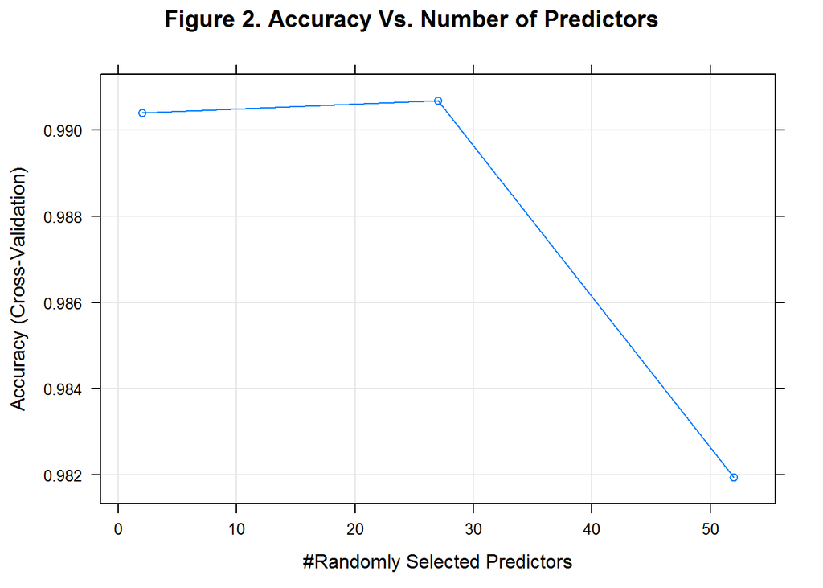

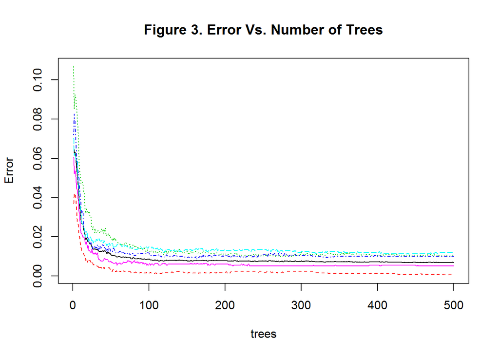

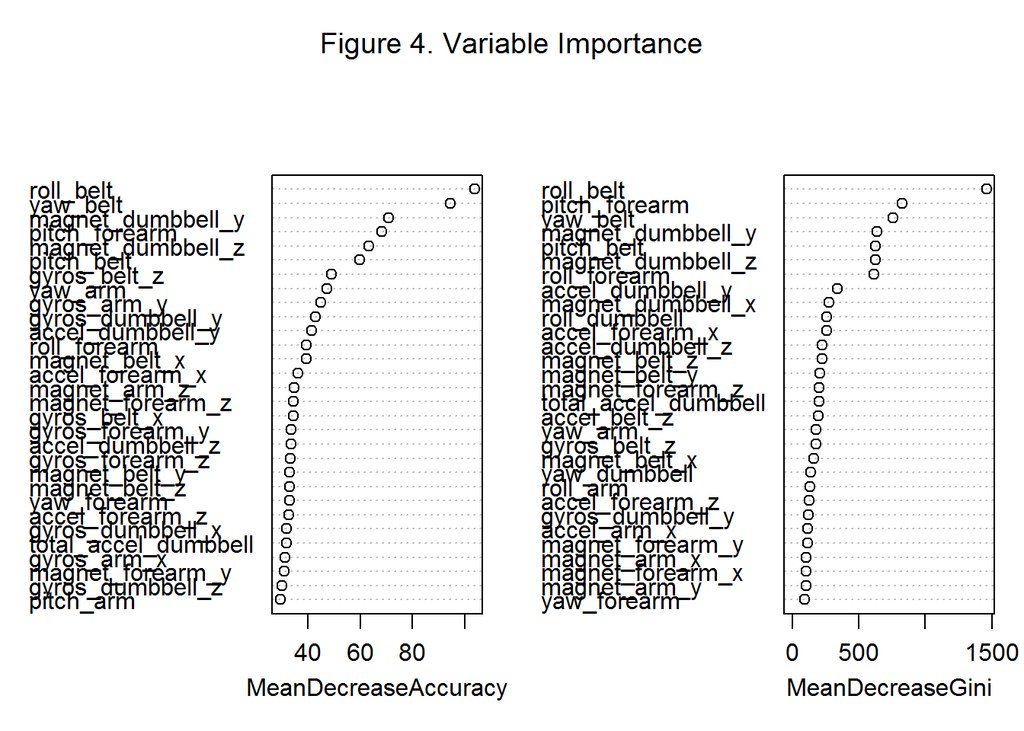

### References

1. Velloso, E.; Bulling, A.; Gellersen, H.; Ugulino, W.; Fuks, H. [Qualitative Activity Recognition of Weight Lifting Exercises](http://groupware.les.inf.puc-rio.br/public/papers/2013.Velloso.QAR-WLE.pdf), Proceedings of 4th International Conference in Cooperation with SIGCHI (Augmented Human ’13) . Stuttgart, Germany: ACM SIGCHI, 2013.]
2. Ugulino, W.; Cardador, D.; Vega, K.; Velloso, E.; Milidiu, R.; Fuks, H. [Wearable Computing: Accelerometers’ Data Classification of Body Postures and Movements](http://groupware.les.inf.puc-rio.br/work.jsf?p1=10335), Proceedings of 21st Brazilian Symposium on Artificial Intelligence. Advances in Artificial Intelligence - SBIA 2012. Lecture Notes in Computer Science. , pp. 52-61. Curitiba, PR: Springer Berlin / Heidelberg, 2012. ISBN 978-3-642-34458-9. DOI: 10.1007/978-3-642-34459-6_6.
3. [Random Forests Classifier Description](http://stat-www.berkeley.edu/users/breiman/RandomForests/cc_home.htm) (Site of Leo Breiman)